# Heart rate detection and stress

Tamas Nagy

2023-05-09

# Project setup

The following analysis report contains the descriptive and inferential statistics for the experiment that investigated how physiological and subjective arousal might be mediated by cardioceptive accuracy.

# Sample characteristics

|  | Value (SD) | Range | Distribution |
| --- | --- | --- | --- |
| N | 67 (0) | 67 - 67 | ▁▁▇▁▁ |
| Male % | 50.7 (50.4) | 0.0 - 100.0 | ▇▁▁▁▇ |
| Mean age (years) | 22.2 (2.2) | 19.0 - 28.0 | ▆▇▃▃▁ |
| Mean STAI-S baseline | 13.0 (7.5) | 0.0 - 33.0 | ▃▇▃▂▁ |
| Mean BMI (kg/m<sup>2</sup>) | 23.1 (3.2) | 17.8 - 31.5 | ▅▇▅▂▂ |
| Mean bodyfat % | 24.2 (8.3) | 5.2 - 49.0 | ▂▇▇▃▁ |
| Mean max grip strength (kg) | 33.7 (10.6) | 17.1 - 65.0 | ▇▆▇▂▁ |
| Mean resting HR (bpm) | 76.8 (10.7) | 54.0 - 101.0 | ▂▆▇▆▂ |

# Subjective response to stress

We tested if the tasks were perceived as stressful.

## STAI-S

Controlling for the baseline level of anxiety (measured in the beginning of the session) and the order of the tasks, we found a significant interaction of task and measurement, i.e. the cognitive task was associated with a STAI-S increase over time, while the physical task did not show a significant change.

| Task | Pre-stress | Post-stress<sup>1</sup> |
| --- | --- | --- |
| Handgrip | 11.4 ± 7.4 | 11.0 ± 6.8 (1.0) |
| N-back | 10.9 ± 6.8 | 14.0 ± 7.8 (1.3) |

<sup>1</sup> Values represent the mean (SD) of the STAI-S

|  | STAI-S |  |  |  |  |  |  |
| --- | --- | --- | --- | --- | --- | --- | --- |
| Predictors | Estimates | std. Beta | CI | standardized CI | Statistic | p | df |
| (Intercept) | 1.27 | -0.08 | -0.84 – 3.38 | -0.26 – 0.10 | 1.18 | 0.238 | 255.00 |
| task [N-back] | -0.58 | -0.08 | -1.62 – 0.47 | -0.22 – 0.06 | -1.08 | 0.280 | 255.00 |
| time [t1] | -0.42 | -0.06 | -1.47 – 0.62 | -0.20 – 0.09 | -0.80 | 0.426 | 255.00 |
| stai s t0 sum | 0.77 | 0.78 | 0.65 – 0.88 | 0.66 – 0.90 | 12.67 | **<0.001** | 255.00 |
| task order [Physical first] | 0.61 | 0.08 | -1.19 – 2.41 | -0.16 – 0.33 | 0.67 | 0.504 | 255.00 |
| task [N-back] * time [t1] | 3.57 | 0.49 | 2.09 – 5.06 | 0.29 – 0.70 | 4.74 | **<0.001** | 255.00 |
| Random Effects |  |  |  |  |  |  |  |
| σ<sup>2</sup> | 9.35 |  |  |  |  |  |  |
| τ<sub>00</sub> <sub>id</sub> | 10.54 |  |  |  |  |  |  |
| ICC | 0.53 |  |  |  |  |  |  |
| N <sub>id</sub> | 66 |  |  |  |  |  |  |
| Observations | 263 |  |  |  |  |  |  |
| Marginal R<sup>2</sup> / Conditional R<sup>2</sup> | 0.628 / 0.825 |  |  |  |  |  |  |
| AICc | 1458.007 |  |  |  |  |  |  |

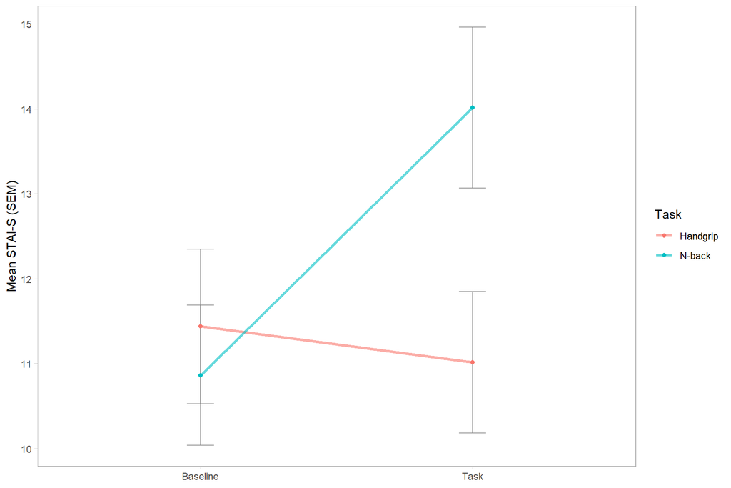

| task | metric | Mean | SD | STAI-S Before | STAI-S After | Expected stress | Expected HR | Perceived HR |
| --- | --- | --- | --- | --- | --- | --- | --- | --- |
| Handgrip | STAI-S Before | 11.4 | 7.4 | 1.00 | 0.90 | −0.14 | −0.08 | −0.12 |
| Handgrip | STAI-S After | 11.0 | 6.8 | 0.90 | 1.00 | −0.11 | −0.08 | −0.14 |
| Handgrip | Expected stress | 33.4 | 24.6 | −0.14 | −0.11 | 1.00 | 0.22 | 0.04 |
| Handgrip | Expected HR | 5.3 | 0.7 | −0.08 | −0.08 | 0.22 | 1.00 | 0.31 |
| Handgrip | Perceived HR | 5.0 | 0.7 | −0.12 | −0.14 | 0.04 | 0.31 | 1.00 |
| N-back | STAI-S Before | 10.9 | 6.8 | 1.00 | 0.80 | 0.04 | 0.06 | 0.15 |
| N-back | STAI-S After | 14.0 | 7.8 | 0.80 | 1.00 | 0.21 | 0.19 | 0.39 |
| N-back | Expected stress | 48.1 | 26.4 | 0.04 | 0.21 | 1.00 | 0.53 | 0.29 |
| N-back | Expected HR | 5.1 | 0.6 | 0.06 | 0.19 | 0.53 | 1.00 | 0.45 |
| N-back | Perceived HR | 5.3 | 0.6 | 0.15 | 0.39 | 0.29 | 0.45 | 1.00 |

The subjective stress measure also showed, that participants regarded the mental stressor to be more stressful than the physical stressor.

|  | STAI-S |  |  |  |  |  |  |
| --- | --- | --- | --- | --- | --- | --- | --- |
| Predictors | Estimates | std. Beta | CI | standardized CI | Statistic | p | df |
| (Intercept) | 31.06 | -0.46 | 19.20 – 42.91 | -0.72 – -0.20 | 5.18 | **<0.001** | 126.00 |
| name [N-back] | 26.56 | 0.96 | 19.77 – 33.35 | 0.72 – 1.21 | 7.74 | **<0.001** | 126.00 |
| stai s t0 sum | -0.09 | -0.02 | -0.76 – 0.58 | -0.20 – 0.16 | -0.26 | 0.796 | 126.00 |
| task order [Physical first] | -1.38 | -0.05 | -11.51 – 8.75 | -0.42 – 0.32 | -0.27 | 0.787 | 126.00 |
| Random Effects |  |  |  |  |  |  |  |
| σ<sup>2</sup> | 388.79 |  |  |  |  |  |  |
| τ<sub>00</sub> <sub>id</sub> | 211.62 |  |  |  |  |  |  |
| ICC | 0.35 |  |  |  |  |  |  |
| N <sub>id</sub> | 66 |  |  |  |  |  |  |
| Observations | 132 |  |  |  |  |  |  |
| Marginal R<sup>2</sup> / Conditional R<sup>2</sup> | 0.229 / 0.501 |  |  |  |  |  |  |

```
##
##  Paired t-test
##
## data:  value by name
## t = -7.7382, df = 65, p-value = 8.518e-11
## alternative hypothesis: true mean difference is not equal to 0
## 95 percent confidence interval:
##  -33.41559 -19.70562
## sample estimates:
## mean difference
##       -26.56061
```

# Psychophysiological response to stress

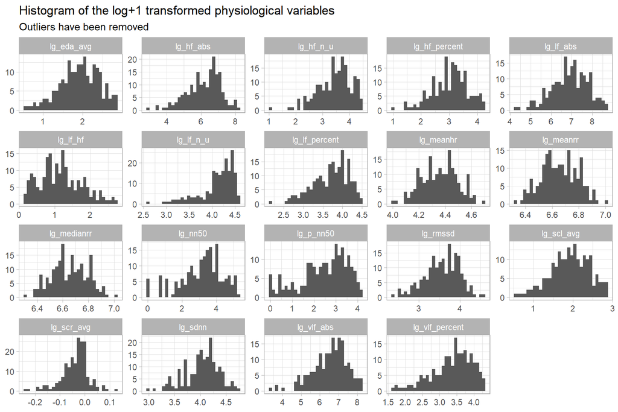

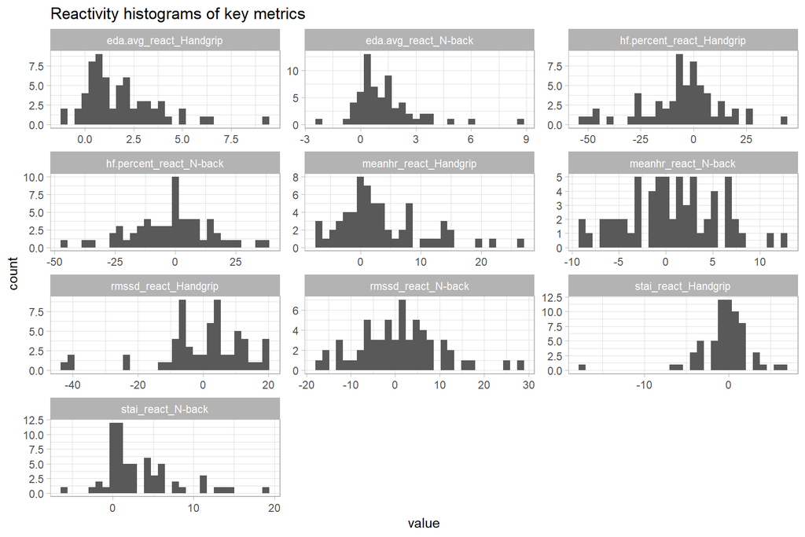

# Analysis of the effects of the tasks on physiological variables

## Descriptive statistics

| metric | name | mean | sd |
| --- | --- | --- | --- |
| NA | ca | 0.54 | 0.27 |
| NA | hrp | 0.93 | 0.13 |
| Mean HR (bpm) | meanhr | 77.90 | 10.61 |
| HF% (log %) | lg_hf_percent | 3.02 | 0.63 |
| RMSSD (log ms) | lg_rmssd | 3.56 | 0.42 |
| Mean EDA (log uS) | lg_eda_avg | 1.92 | 0.49 |

## Visualize phys changes

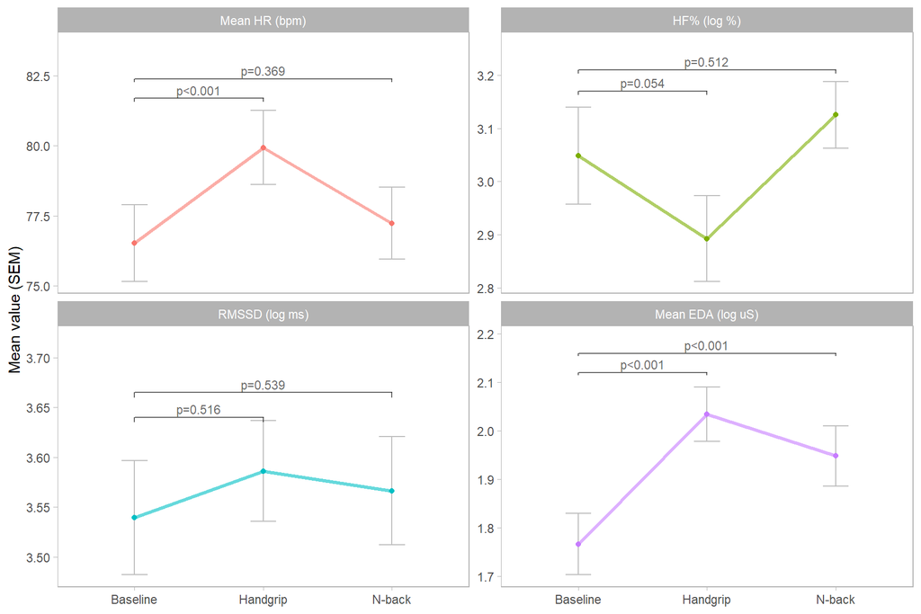

## Change stats in %

|  | Baseline | Handgrip | N-back |
| --- | --- | --- | --- |
| Mean HR (bpm) | 76.52 ± 10.92 | 79.94 ± 10.51 (104.5%) | 77.23 ± 10.24 (100.9%) |
| HF% (log %) | 3.05 ± 0.71 | 2.89 ± 0.64 (94.8%) | 3.13 ± 0.50 (102.5%) |
| RMSSD (log ms) | 3.54 ± 0.45 | 3.59 ± 0.40 (101.3%) | 3.57 ± 0.42 (100.7%) |
| Mean EDA (log uS) | 1.77 ± 0.50 | 2.03 ± 0.45 (114.9%) | 1.95 ± 0.49 (110.0%) |

## Reactivity measures

### Variables

Reactivity (task - baseline) values were calculated for EDA average, HF%, RMSSD, HR average, and STAI.

### Results

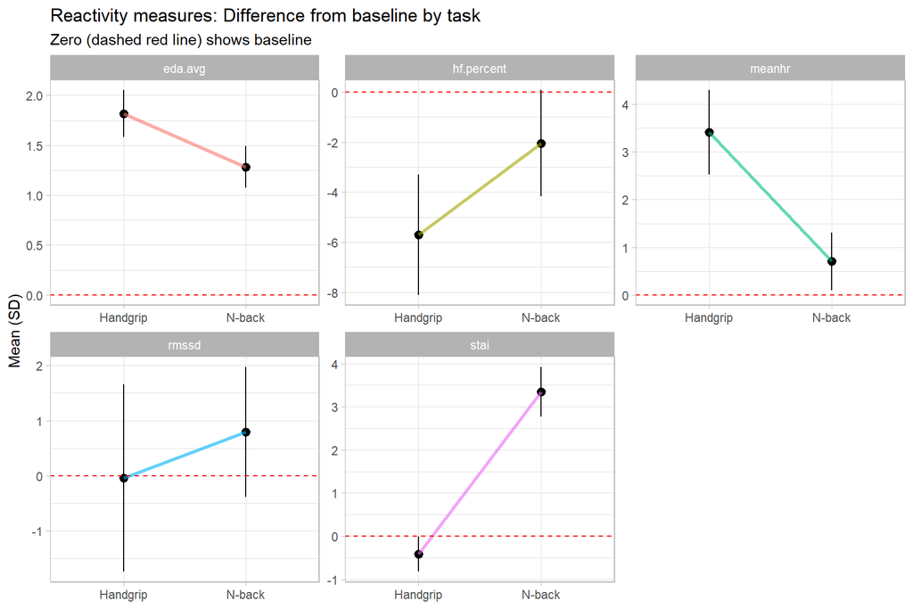

# Creating tables and visualizations

| metric | ca | hrp |
| --- | --- | --- |
| Mean HR (bpm) | -0.02 | 0.11 |
| HF% (%) | -0.01 | 0.11 |
| RMSSD (ms) | -0.16 | -0.10 |
| Mean EDA (uS) | 0.13 | -0.02 |
| Mean HR (bpm) | 0.01 | 0.15 |
| HF% (%) | 0.08 | 0.08 |
| RMSSD (ms) | -0.17 | 0.02 |
| Mean EDA (uS) | 0.11 | 0.14 |

## HBP and HRP corr figure

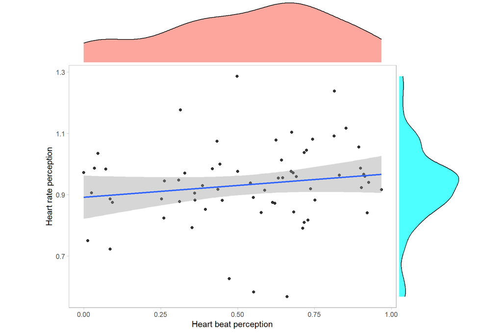

## Correlation between pooled physiological measurements and cardioceptive metrics

We did not find a relationship between cardioceptive accuracy and physiological reactivity measures (HR, RMSSD, HF%, EDA) in any of the tasks. However, CA was negatively associated with HR and positively with lgRMSSD. Similarly, heart rate perception was negatively associated with HR and positively with lgRMSSD, but did not moderate the reaction to stress.

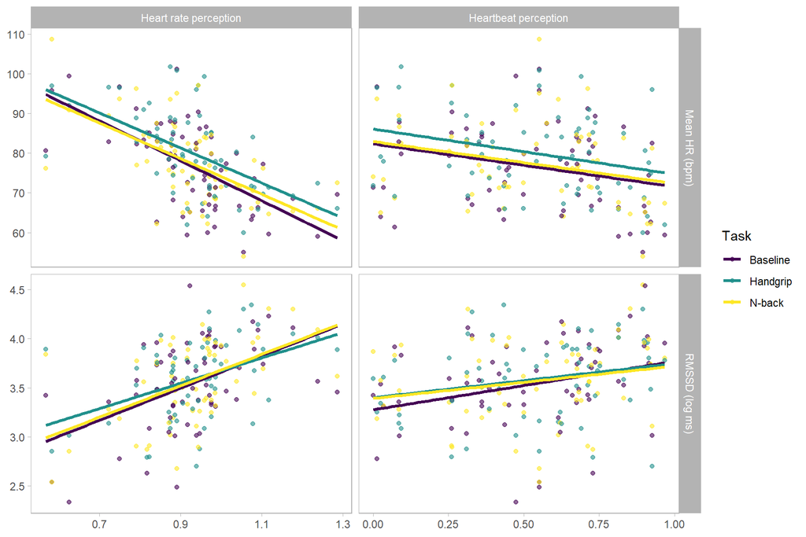

# Hypothesis tests

## H1-2

Perceived stress in both conditions [mental_experienced_stress; physical_experienced_stress / STAI-S_mental_after – STAI-S_mental_before; STAI-S_physical_after - STAI-S_physical_before] is predicted by cardioceptive accuracy [cardioceptive_accuracy], physiological reactions [ΔHRmental, ΔEDAmental, ΔRMSSDmental, ΔHFmental; ΔHRphysical, ΔEDAphysical, ΔRMSSDphysical, ΔHFphysical], and stress related expectations [mental_expected_stress; physical_expected_stress]

We fitted linear regressions for each task (N-back and physical) separately. We investigated if physiological changes, cardioceptive accuracy (HBP), or expected stress predicted STAI-S change in the respective tasks. We used task order as a covariate.

| term | estimate | std.error | conf.low | conf.high | statistic | p.value |
| --- | --- | --- | --- | --- | --- | --- |
| N-back_stai_meanhr_ca |  |  |  |  |  |  |
| (Intercept) | −0.05 | 0.23 | −0.51 | 0.41 | −0.211 | 0.833 |
| ca | 0.03 | 0.12 | −0.21 | 0.28 | 0.259 | 0.796 |
| meanhr | 0.01 | 0.13 | −0.24 | 0.27 | 0.114 | 0.910 |
| mental_expected_stress | 0.29 | 0.13 | 0.03 | 0.54 | 2.285 | 0.026 |
| bodyfat_percent | 0.30 | 0.17 | −0.03 | 0.64 | 1.817 | 0.075 |
| sexMale | −0.03 | 0.33 | −0.70 | 0.63 | −0.099 | 0.922 |
| task_orderPhysical first | 0.19 | 0.26 | −0.32 | 0.70 | 0.734 | 0.466 |
| ca:meanhr | −0.09 | 0.15 | −0.38 | 0.21 | −0.585 | 0.561 |
| N-back_stai_meanhr_hrp |  |  |  |  |  |  |
| (Intercept) | −0.03 | 0.23 | −0.49 | 0.42 | −0.141 | 0.888 |
| hrp | −0.13 | 0.13 | −0.40 | 0.13 | −1.014 | 0.315 |
| meanhr | 0.12 | 0.13 | −0.15 | 0.38 | 0.872 | 0.387 |
| mental_expected_stress | 0.21 | 0.13 | −0.04 | 0.46 | 1.690 | 0.097 |
| bodyfat_percent | 0.37 | 0.17 | 0.04 | 0.71 | 2.221 | 0.031 |
| sexMale | −0.06 | 0.34 | −0.73 | 0.61 | −0.179 | 0.859 |
| task_orderPhysical first | 0.10 | 0.25 | −0.40 | 0.60 | 0.403 | 0.689 |
| hrp:meanhr | 0.21 | 0.10 | 0.01 | 0.41 | 2.070 | 0.043 |
| Handgrip_stai_meanhr_ca |  |  |  |  |  |  |
| (Intercept) | 0.41 | 0.23 | −0.04 | 0.87 | 1.824 | 0.074 |
| ca | 0.07 | 0.13 | −0.19 | 0.33 | 0.525 | 0.602 |
| meanhr | −0.12 | 0.12 | −0.36 | 0.13 | −0.953 | 0.345 |
| physical_expected_stress | 0.11 | 0.12 | −0.13 | 0.36 | 0.909 | 0.367 |
| bodyfat_percent | −0.35 | 0.17 | −0.69 | −0.01 | −2.084 | 0.042 |
| sexMale | −0.94 | 0.32 | −1.58 | −0.30 | −2.956 | 0.005 |
| task_orderPhysical first | 0.15 | 0.26 | −0.36 | 0.66 | 0.577 | 0.566 |
| ca:meanhr | −0.25 | 0.13 | −0.51 | 0.01 | −1.902 | 0.062 |
| Handgrip_stai_meanhr_hrp |  |  |  |  |  |  |
| (Intercept) | 0.38 | 0.21 | −0.05 | 0.81 | 1.790 | 0.079 |
| hrp | −0.20 | 0.13 | −0.45 | 0.05 | −1.572 | 0.122 |

[output cut: 114 more lines]

| model | term | estimate | std.error | conf.low | conf.high | statistic | p.value |
| --- | --- | --- | --- | --- | --- | --- | --- |
| Handgrip_stai_meanhr_hrp | hrp:meanhr | −0.45 | 0.11 | −0.68 | −0.23 | −4.003 | 0.000 |
| N-back_stai_eda.avg_ca | mental_expected_stress | 0.30 | 0.12 | 0.06 | 0.54 | 2.509 | 0.015 |
| N-back_stai_eda.avg_hrp | mental_expected_stress | 0.28 | 0.12 | 0.04 | 0.52 | 2.316 | 0.024 |
| N-back_stai_hf.percent_ca | mental_expected_stress | 0.31 | 0.13 | 0.05 | 0.57 | 2.407 | 0.020 |
| N-back_stai_hf.percent_hrp | mental_expected_stress | 0.32 | 0.13 | 0.07 | 0.58 | 2.560 | 0.013 |
| N-back_stai_meanhr_ca | mental_expected_stress | 0.29 | 0.13 | 0.03 | 0.54 | 2.285 | 0.026 |
| N-back_stai_meanhr_hrp | hrp:meanhr | 0.21 | 0.10 | 0.01 | 0.41 | 2.070 | 0.043 |
| N-back_stai_rmssd_ca | mental_expected_stress | 0.30 | 0.11 | 0.08 | 0.53 | 2.677 | 0.010 |
| N-back_stai_rmssd_ca | rmssd | 0.27 | 0.12 | 0.04 | 0.51 | 2.341 | 0.023 |
| N-back_stai_rmssd_hrp | mental_expected_stress | 0.30 | 0.12 | 0.07 | 0.54 | 2.626 | 0.011 |
| N-back_stai_rmssd_hrp | rmssd | 0.30 | 0.12 | 0.06 | 0.53 | 2.549 | 0.014 |

|  | metric | estimate_phys_change | estimate_expected_stress | estimate_ca:phys_change |
| --- | --- | --- | --- | --- |
| Handgrip |  |  |  |  |
| ca | Mean HR (bpm) | −0.12 | 0.11 | −0.25 |
| ca | HF% (%) | −0.08 | 0.09 | 0.04 |
| ca | RMSSD (ms) | −0.15 | 0.11 | 0.02 |
| ca | Mean EDA (uS) | −0.06 | 0.12 | 0.10 |
| hrp | Mean HR (bpm) | −0.04 | 0.14 | −0.45 *** |
| hrp | HF% (%) | −0.05 | 0.07 | −0.09 |
| hrp | RMSSD (ms) | −0.12 | 0.08 | −0.04 |
| hrp | Mean EDA (uS) | −0.02 | 0.07 | 0.10 |
| N-back |  |  |  |  |
| ca | Mean HR (bpm) | 0.01 | 0.29 * | −0.09 |
| ca | HF% (%) | 0.06 | 0.31 * | −0.11 |
| ca | RMSSD (ms) | 0.27 * | 0.30 ** | 0.22 |
| ca | Mean EDA (uS) | −0.25 | 0.30 * | −0.05 |
| hrp | Mean HR (bpm) | 0.12 | 0.21 | 0.21 * |
| hrp | HF% (%) | 0.04 | 0.32 * | −0.33 |
| hrp | RMSSD (ms) | 0.30 * | 0.30 * | −0.15 |
| hrp | Mean EDA (uS) | −0.26 | 0.28 * | −0.20 |

### Figure: CA/HRP moderates the association of objective and subjective change metrics

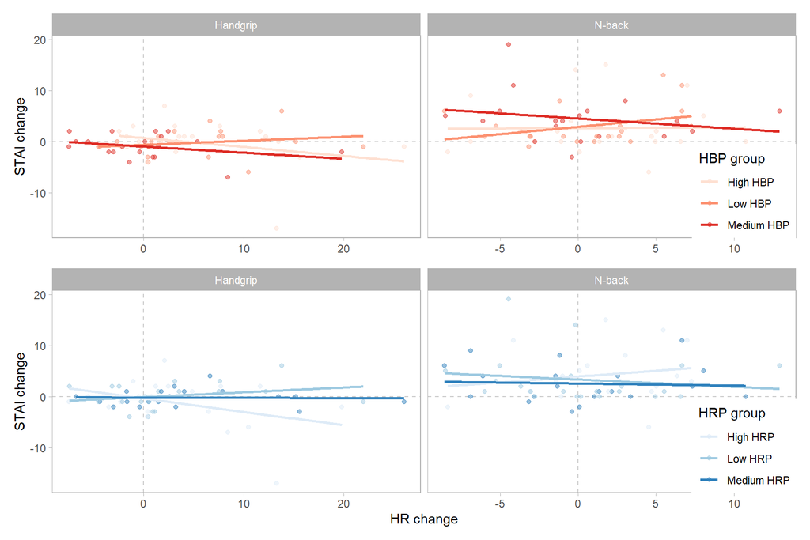

## H3

Perceived HR in both conditions [mental_experienced_HR_change; physical_experienced_HR_change] is predicted by actual change [ΔHRmental, ΔHRphysical] and HR-related expectations [mental_expected_HR_change; physical_expected_HR_change] in both conditions

We used a path analysis to include all variables in the same model. We included sex, body fat percent, and task order as covariates.

```
## lavaan 0.6-12 ended normally after 129 iterations
##
##   Estimator                                         ML
##   Optimization method                           NLMINB
##   Number of model parameters                        40
##
##   Number of observations per group:               Used       Total
##     N-back                                          62          64
##     Handgrip                                        63          64
##
## Model Test User Model:
##
##   Test statistic                                28.233
##   Degrees of freedom                                12
##   P-value (Chi-square)                           0.005
##   Test statistic for each group:
##     N-back                                      13.496
##     Handgrip                                    14.737
##
## Model Test Baseline Model:
##
##   Test statistic                                82.405
##   Degrees of freedom                                36
##   P-value                                        0.000
##
## User Model versus Baseline Model:
##
##   Comparative Fit Index (CFI)                    0.650
##   Tucker-Lewis Index (TLI)                      -0.049
##
## Loglikelihood and Information Criteria:
##
##   Loglikelihood user model (H0)               -968.144
##   Loglikelihood unrestricted model (H1)             NA
##
##   Akaike (AIC)                                2016.288
##   Bayesian (BIC)                              2129.420
##   Sample-size adjusted Bayesian (BIC)         2002.933
##
## Root Mean Square Error of Approximation:
```

[output cut: 72 more lines]

```
##     bodyfat_percnt    0.093    0.153    0.612    0.541    0.093    0.102
##
## Intercepts:
##                    Estimate  Std.Err  z-value  P(>|z|)   Std.lv  Std.all
##    .stai             -1.984    1.260   -1.574    0.115   -1.984   -0.615
##    .experiencedhr     0.015    0.273    0.054    0.957    0.015    0.020
##    .expectedhr       -0.465    0.252   -1.847    0.065   -0.465   -0.680
##    .meanhr           -1.738    4.351   -0.399    0.690   -1.738   -0.249
##
## Variances:
##                    Estimate  Std.Err  z-value  P(>|z|)   Std.lv  Std.all
##    .stai             10.260    1.828    5.612    0.000   10.260    0.986
##    .experiencedhr     0.482    0.086    5.612    0.000    0.482    0.895
##    .expectedhr        0.432    0.077    5.612    0.000    0.432    0.925
##    .meanhr           47.681    8.496    5.612    0.000   47.681    0.976
```

Model Summary

| Parameter | Coefficient | SE | 95% CI | z | p |
| --- | --- | --- | --- | --- | --- |
| 1.00 - Regression |  |  |  |  |  |
| stai ~ expectedhr | 0.04 | 0.13 | (-0.20, 0.29) | 0.35 | 0.726 |
| stai ~ experiencedhr | 0.47 | 0.11 | (0.25, 0.69) | 4.15 | < .001 |
| stai ~ meanhr | 1.30e-04 | 0.11 | (-0.22, 0.22) | 1.16e-03 | > .999 |
| stai ~ task_order | 0.17 | 0.11 | (-0.05, 0.39) | 1.49 | 0.135 |
| experiencedhr ~ expectedhr | 0.47 | 0.10 | (0.27, 0.67) | 4.58 | < .001 |
| experiencedhr ~ meanhr | 0.06 | 0.11 | (-0.17, 0.28) | 0.51 | 0.612 |
| experiencedhr ~ task_order | 0.05 | 0.12 | (-0.18, 0.28) | 0.42 | 0.671 |
| expectedhr ~ task_order | -0.19 | 0.12 | (-0.43, 0.05) | -1.54 | 0.124 |
| meanhr ~ expectedhr | 0.03 | 0.13 | (-0.22, 0.27) | 0.22 | 0.822 |
| meanhr ~ task_order | -0.19 | 0.12 | (-0.43, 0.05) | -1.54 | 0.123 |
| meanhr ~ sex | 0.18 | 0.16 | (-0.13, 0.49) | 1.13 | 0.257 |
| meanhr ~ bodyfat_percent | 0.06 | 0.16 | (-0.26, 0.38) | 0.35 | 0.729 |
| 2.00 - Regression |  |  |  |  |  |
| stai ~ expectedhr | 0.02 | 0.14 | (-0.25, 0.28) | 0.12 | 0.906 |
| stai ~ experiencedhr | -0.02 | 0.13 | (-0.28, 0.24) | -0.15 | 0.883 |
| stai ~ meanhr | -0.12 | 0.13 | (-0.36, 0.13) | -0.92 | 0.356 |
| stai ~ task_order | 0.02 | 0.13 | (-0.24, 0.27) | 0.12 | 0.906 |
| experiencedhr ~ expectedhr | 0.32 | 0.12 | (0.09, 0.55) | 2.73 | 0.006 |
| experiencedhr ~ meanhr | 0.08 | 0.12 | (-0.15, 0.32) | 0.70 | 0.482 |
| experiencedhr ~ task_order | -0.11 | 0.12 | (-0.35, 0.14) | -0.86 | 0.390 |
| expectedhr ~ task_order | 0.27 | 0.11 | (0.05, 0.50) | 2.40 | 0.017 |
| meanhr ~ expectedhr | 0.05 | 0.13 | (-0.21, 0.30) | 0.37 | 0.714 |
| meanhr ~ task_order | 0.10 | 0.13 | (-0.16, 0.35) | 0.76 | 0.449 |
| meanhr ~ sex | 0.05 | 0.16 | (-0.27, 0.37) | 0.31 | 0.760 |
| meanhr ~ bodyfat_percent | 0.10 | 0.17 | (-0.22, 0.43) | 0.61 | 0.539 |
| 1.00 - Correlation |  |  |  |  |  |
| task_order ~~ sex | -0.09 | 0.00 | (-0.09, -0.09) |  | < .001 |
| task_order ~~ bodyfat_percent | 0.19 | 0.00 | (0.19, 0.19) |  | < .001 |
| sex ~~ bodyfat_percent | -0.65 | 0.00 | (-0.65, -0.65) |  | < .001 |
| 2.00 - Correlation |  |  |  |  |  |
| task_order ~~ sex | -0.08 | 0.00 | (-0.08, -0.08) |  | < .001 |
| task_order ~~ bodyfat_percent | 0.17 | 0.00 | (0.17, 0.17) |  | < .001 |
| sex ~~ bodyfat_percent | -0.65 | 0.00 | (-0.65, -0.65) |  | < .001 |

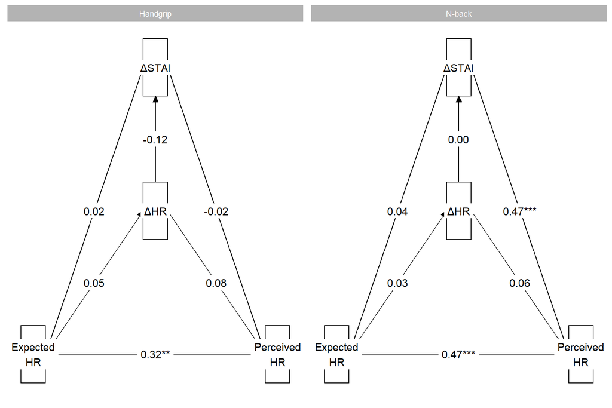